# Peer Assessment II

# 1 Background

As a statistical consultant working for a real estate investment firm, your task is to develop a model to predict the selling price of a given home in Ames, Iowa. Your employer hopes to use this information to help assess whether the asking price of a house is higher or lower than the true value of the house. If the home is undervalued, it may be a good investment for the firm.

# 2 Training Data and relevant packages

In order to better assess the quality of the model you will produce, the data have been randomly divided into three separate pieces: a training data set, a testing data set, and a validation data set. For now we will load the training data set, the others will be loaded and used later.

```r
setwd("~/coursera/statistics/capstone/week8/")

load("ames_train.Rdata")
```

Use the code block below to load any necessary packages

```r
library(statsr)
library(MASS)
library(dplyr)
library(BAS)
```

```r
library(pander)
panderOptions('table.split.table', Inf)
library(ggplot2)
```

## 2.1 Part 1 - Exploratory Data Analysis (EDA)

When you first get your data, it’s very tempting to immediately begin fitting models and assessing how they perform. However, before you begin modeling, it’s absolutely essential to explore the structure of the data and the relationships between the variables in the data set.

Do a detailed EDA of the ames_train data set, to learn about the structure of the data and the relationships between the variables in the data set (refer to Introduction to Probability and Data, Week 2, for a reminder about EDA if needed). Your EDA should involve creating and reviewing many plots/graphs and considering the patterns and relationships you see.

After you have explored completely, submit the three graphs/plots that you found most informative during your EDA process, and briefly explain what you learned from each (why you found each informative).

### 2.1.1 Price By Area

Applying log on price and area we got a good correlation between this two variables.

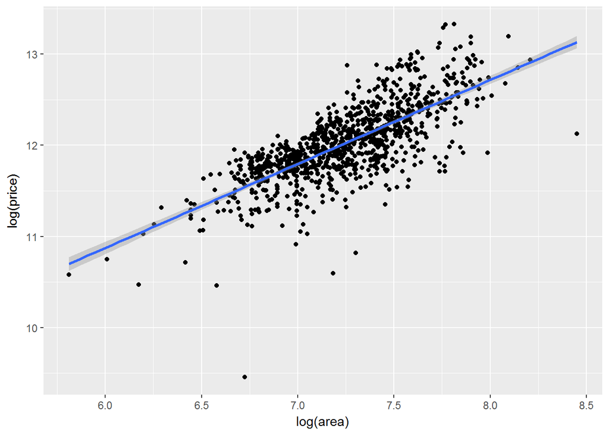

```r
ames_train %>%
  select(price, area) %>%
  ggplot(aes(x= log(area), y = log(price))) +
  geom_point() + stat_smooth(method=lm)
```

With a string correlation:

```r
model <- lm(ames_train, formula = log(price) ~log(area))
summary(model)
```

```
##
## Call:
## lm(formula = log(price) ~ log(area), data = ames_train)
##
## Residuals:
##      Min       1Q   Median       3Q      Max
## -2.08526 -0.14145  0.02048  0.17002  0.84536
##
## Coefficients:
##             Estimate Std. Error t value Pr(>|t|)
## (Intercept)  5.34441    0.19262   27.75   <2e-16 ***
## log(area)    0.92167    0.02657   34.69   <2e-16 ***
## ---
## Signif. codes:  0 '***' 0.001 '**' 0.01 '*' 0.05 '.' 0.1 ' ' 1
##
## Residual standard error: 0.2834 on 998 degrees of freedom
## Multiple R-squared:  0.5466, Adjusted R-squared:  0.5461
## F-statistic:  1203 on 1 and 998 DF,  p-value: < 2.2e-16
```

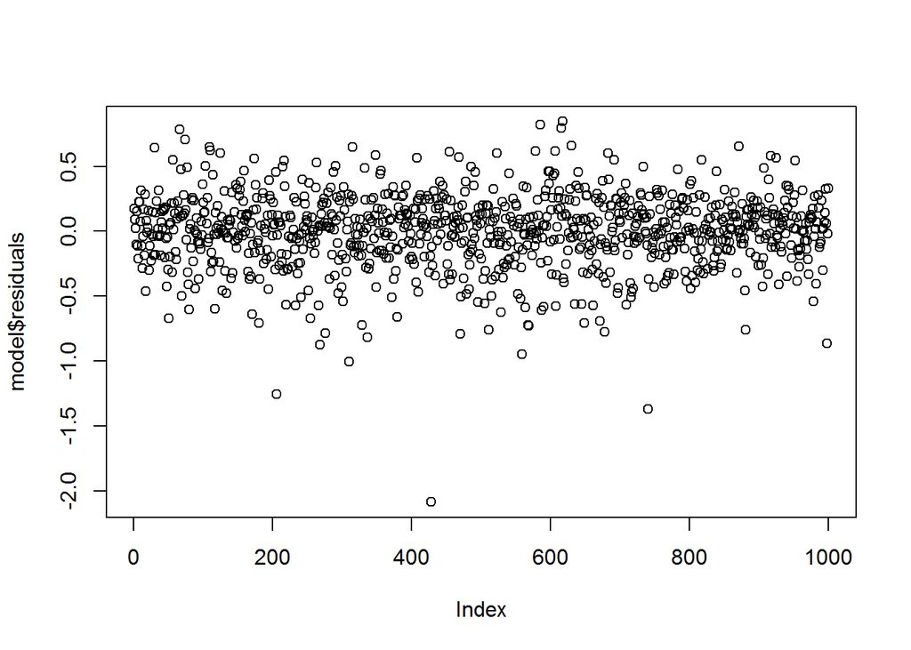

```r
plot(model$residuals)
```

This indicates that the residuals are nearnly normal and the variability is constant.

### 2.1.2 NAs on dataset

Let’s see how NA values are distribuited by the data set

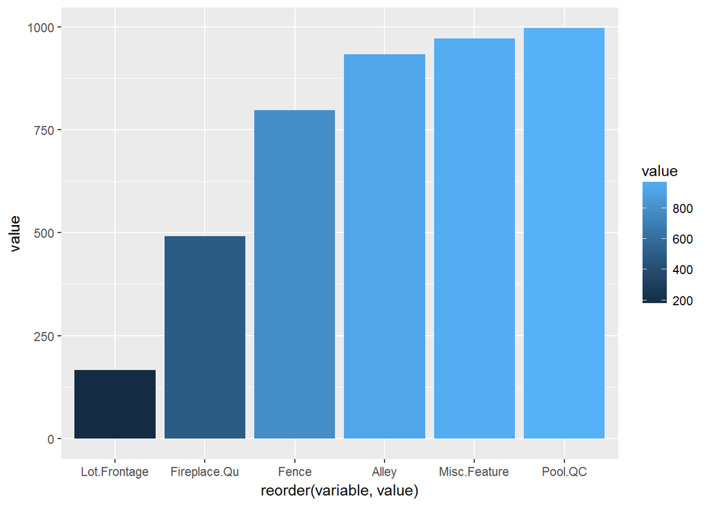

```r
na_count <- sapply(ames_train, function(y) sum(length(which(is.na(y)))))
na_count <- na_count %>% as.data.frame()
na_count <- data.frame(variable = rownames(na_count), v = na_count)
names(na_count) <- c("variable", "value")
na_count <- na_count %>%
  arrange(desc(value))

na_count$variable <- factor(na_count$variable)

na_count %>%
  filter(value > 50) %>%
  arrange(desc(value)) %>%
  ggplot(aes(x = reorder(variable, value), y = value, fill = value)) +
  geom_bar(stat = "identity")
```

Six variables are responsible for almost all NAs in dataset, now we are awareness about this issue, so our modeling process will be more effective.

### 2.1.3 Quality/Condition vs Price

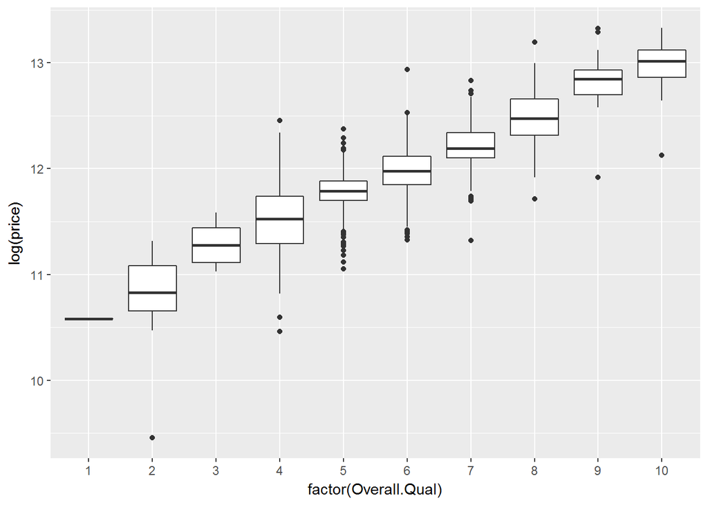

```r
ames_train %>%
  select(Overall.Qual, Overall.Cond, price) %>%
  ggplot(aes(group=Overall.Qual, x= factor(Overall.Qual), y = log(price))) +
  geom_boxplot()
```

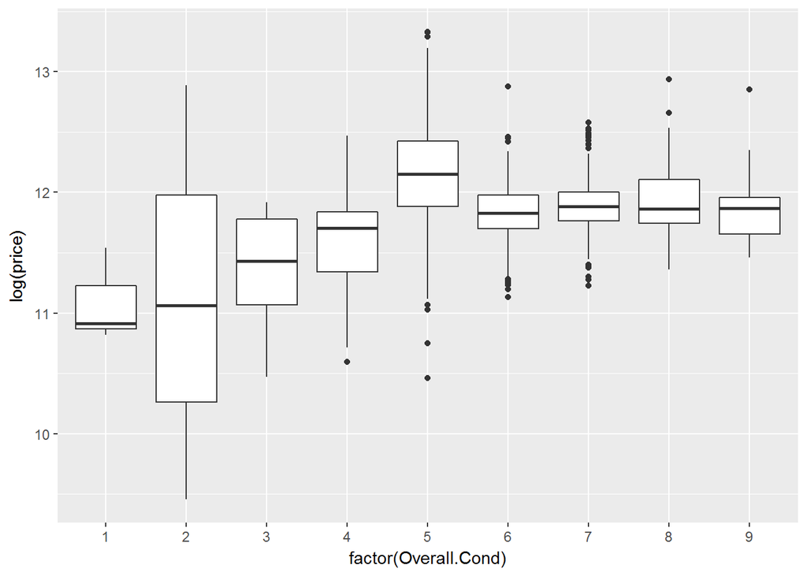

```r
ames_train %>%
  select(Overall.Cond, price) %>%
  ggplot(aes(x= factor(Overall.Cond), y = log(price))) +
  geom_boxplot()
```

The overall condition of a house has a increase in the price until reach 5, after that the price varies but does not increases too much, on the other hand the quality of the materials has a linear improvement in house price.

It is funny (to me) that the intuition of House Condition must be high related with House Quality falls to ground.

## 2.2 Part 2 - Development and assessment of an initial model, following a semi-guided process of analysis

### 2.2.1 Section 2.1 An Initial Model

In building a model, it is often useful to start by creating a simple, intuitive initial model based on the results of the exploratory data analysis. (Note: The goal at this stage is **not** to identify the “best” possible model but rather to choose a reasonable and understandable starting point. Later you will expand and revise this model to create your final model.

Based on your EDA, select *at most* 10 predictor variables from âames_trainâ and create a linear model for `price` (or a transformed version of price) using those variables. Provide the *R code* and the *summary output table* for your model, a *brief justification* for the variables you have chosen, and a *brief discussion* of the model results in context (focused on the variables that appear to be important predictors and how they relate to sales price).

```r
model <- lm(data = ames_train,
            formula = log(price) ~ log(area) + log(Lot.Area) + Neighborhood + Overall.Qual + Year.Built + Exter.Qual + Heating + Sale.Condition + Kitchen.Qual + Bedroom.AbvGr)

summary(model)
```

```
##
## Call:
## lm(formula = log(price) ~ log(area) + log(Lot.Area) + Neighborhood +
##     Overall.Qual + Year.Built + Exter.Qual + Heating + Sale.Condition +
##     Kitchen.Qual + Bedroom.AbvGr, data = ames_train)
##
## Residuals:
##      Min       1Q   Median       3Q      Max
## -1.64429 -0.06893  0.00534  0.08090  0.60620
##
## Coefficients:
##                         Estimate Std. Error t value Pr(>|t|)
## (Intercept)            1.1388394  0.8917090   1.277  0.20186
## log(area)              0.4561921  0.0277414  16.444  < 2e-16 ***
## log(Lot.Area)          0.1084976  0.0143308   7.571 8.74e-14 ***
## NeighborhoodBlueste   -0.0406436  0.1032693  -0.394  0.69399
## NeighborhoodBrDale    -0.1581231  0.0716248  -2.208  0.02751 *
## NeighborhoodBrkSide    0.0142113  0.0612584   0.232  0.81660
## NeighborhoodClearCr    0.0760704  0.0719172   1.058  0.29044
## NeighborhoodCollgCr   -0.0245124  0.0527878  -0.464  0.64250
## NeighborhoodCrawfor    0.1449876  0.0612344   2.368  0.01810 *
## NeighborhoodEdwards   -0.0811328  0.0561000  -1.446  0.14844
## NeighborhoodGilbert   -0.0831416  0.0552329  -1.505  0.13258
## NeighborhoodGreens     0.0938332  0.0923974   1.016  0.31011
## NeighborhoodGrnHill    0.2849124  0.1206622   2.361  0.01841 *
## NeighborhoodIDOTRR    -0.1721032  0.0629186  -2.735  0.00635 **
## NeighborhoodMeadowV   -0.1318791  0.0654505  -2.015  0.04419 *
## NeighborhoodMitchel    0.0208707  0.0572088   0.365  0.71533
## NeighborhoodNAmes      0.0224477  0.0547489   0.410  0.68189
## NeighborhoodNoRidge    0.0764211  0.0585567   1.305  0.19218
## NeighborhoodNPkVill   -0.0294897  0.0927414  -0.318  0.75057
## NeighborhoodNridgHt    0.0710639  0.0542605   1.310  0.19062
## NeighborhoodNWAmes    -0.0286007  0.0574653  -0.498  0.61881
## NeighborhoodOldTown   -0.0713671  0.0611488  -1.167  0.24346
## NeighborhoodSawyer     0.0170701  0.0571284   0.299  0.76516
## NeighborhoodSawyerW   -0.0924468  0.0550355  -1.680  0.09333 .
## NeighborhoodSomerst    0.0029835  0.0510461   0.058  0.95341
## NeighborhoodStoneBr    0.1029213  0.0608362   1.692  0.09102 .
## NeighborhoodSWISU     -0.0148570  0.0730910  -0.203  0.83897
## NeighborhoodTimber     0.0383229  0.0620469   0.618  0.53696
```

[output cut: 11 more lines]

```
## Sale.ConditionAlloca   0.2308755  0.0812017   2.843  0.00456 **
## Sale.ConditionFamily  -0.0172653  0.0437836  -0.394  0.69342
## Sale.ConditionNormal   0.1161464  0.0211560   5.490 5.16e-08 ***
## Sale.ConditionPartial  0.1458751  0.0294708   4.950 8.78e-07 ***
## Kitchen.QualFa        -0.2242071  0.0485693  -4.616 4.44e-06 ***
## Kitchen.QualGd        -0.0764578  0.0279818  -2.732  0.00640 **
## Kitchen.QualPo        -0.3285323  0.1665245  -1.973  0.04880 *
## Kitchen.QualTA        -0.1511411  0.0309921  -4.877 1.26e-06 ***
## Bedroom.AbvGr         -0.0314912  0.0086123  -3.657  0.00027 ***
## ---
## Signif. codes:  0 '***' 0.001 '**' 0.01 '*' 0.05 '.' 0.1 ' ' 1
##
## Residual standard error: 0.1554 on 952 degrees of freedom
## Multiple R-squared:  0.8699, Adjusted R-squared:  0.8635
## F-statistic: 135.5 on 47 and 952 DF,  p-value: < 2.2e-16
```

#### 2.2.1.1 Why these variables ?

- *log(area)* and *log(Lot.Area)* : transforming these to log we increse the correlation with log(price)
- Neighborhood : EDA has shown a good correlation with log(price)
- Overall.Qual : EDA has shown a good correlation with log(price)
- Year.Built : EDA has shown a good correlation with log(price)
- Exter.Qual : EDA has shown a good correlation with log(price)
- Heating : EDA has shown a good correlation with log(price)
- Sale.Condition : EDA has shown a good correlation with log(price)
- Kitchen.Qual : EDA has shown a good correlation with log(price)
- Bedroom.AbvGr : EDA has shown a good correlation with log(price)

#### 2.2.1.2 Why these variables are importants ?

Each variable has shown on EDA some relation with the **log(price)** variable, using this intuitive set we could get a Adjusted R-squared of `0.8635`, pretty good for a first model.

### 2.2.2 Section 2.2 Model Selection

Now either using `BAS` another stepwise selection procedure choose the “best” model you can, using your initial model as your starting point. Try at least two different model selection methods and compare their results. Do they both arrive at the same model or do they disagree? What do you think this means?

#### 2.2.2.1 Using stepwise AIC

```r
model_AIC <- stepAIC(model, direction = c('backward'), k = 2, steps = 90000)
```

```
## Start:  AIC=-3676.98
## log(price) ~ log(area) + log(Lot.Area) + Neighborhood + Overall.Qual +
##     Year.Built + Exter.Qual + Heating + Sale.Condition + Kitchen.Qual +
##     Bedroom.AbvGr
##
##                  Df Sum of Sq    RSS     AIC
## <none>                        22.984 -3677.0
## - Heating         4    0.2262 23.210 -3675.2
## - Exter.Qual      3    0.2916 23.275 -3670.4
## - Bedroom.AbvGr   1    0.3228 23.306 -3665.0
## - Kitchen.Qual    4    0.9284 23.912 -3645.4
## - Sale.Condition  5    1.1197 24.103 -3639.4
## - Year.Built      1    1.3326 24.316 -3622.6
## - log(Lot.Area)   1    1.3838 24.367 -3620.5
## - Neighborhood   26    3.8023 26.786 -3575.9
## - Overall.Qual    1    3.7322 26.716 -3528.5
## - log(area)       1    6.5286 29.512 -3429.0
```

```r
summary_AIC <- summary(model)
```

Using AIC model selection criteria we got the same original model with Adj. R^2 of 0.8635284 and R^2 of 0.869949.

#### 2.2.2.2 Using stepwise BIC

```r
stepAIC(model, direction = c('both'), k = log(nrow(ames_train)))
```

```
## Start:  AIC=-3441.4
## log(price) ~ log(area) + log(Lot.Area) + Neighborhood + Overall.Qual +
##     Year.Built + Exter.Qual + Heating + Sale.Condition + Kitchen.Qual +
##     Bedroom.AbvGr
##
##                  Df Sum of Sq    RSS     AIC
## - Neighborhood   26    3.8023 26.786 -3467.9
## - Heating         4    0.2262 23.210 -3459.2
## - Exter.Qual      3    0.2916 23.275 -3449.5
## <none>                        22.984 -3441.4
## - Bedroom.AbvGr   1    0.3228 23.306 -3434.4
## - Kitchen.Qual    4    0.9284 23.912 -3429.4
## - Sale.Condition  5    1.1197 24.103 -3428.4
## - Year.Built      1    1.3326 24.316 -3392.0
## - log(Lot.Area)   1    1.3838 24.367 -3389.8
## - Overall.Qual    1    3.7322 26.716 -3297.8
## - log(area)       1    6.5286 29.512 -3198.3
##
## Step:  AIC=-3467.91
## log(price) ~ log(area) + log(Lot.Area) + Overall.Qual + Year.Built +
##     Exter.Qual + Heating + Sale.Condition + Kitchen.Qual + Bedroom.AbvGr
##
##                  Df Sum of Sq    RSS     AIC
## - Heating         4    0.1110 26.897 -3491.4
## - Exter.Qual      3    0.5317 27.317 -3469.0
## <none>                        26.786 -3467.9
## - Kitchen.Qual    4    0.7824 27.568 -3466.8
## - Sale.Condition  5    1.2752 28.061 -3455.9
## - Bedroom.AbvGr   1    0.5305 27.316 -3455.2
## + Neighborhood   26    3.8023 22.984 -3441.4
## - log(Lot.Area)   1    4.3957 31.182 -3322.9
## - Year.Built      1    4.4501 31.236 -3321.1
## - Overall.Qual    1    5.8326 32.618 -3277.8
## - log(area)       1    7.2976 34.083 -3233.9
##
## Step:  AIC=-3491.41
## log(price) ~ log(area) + log(Lot.Area) + Overall.Qual + Year.Built +
##     Exter.Qual + Sale.Condition + Kitchen.Qual + Bedroom.AbvGr
##
##                  Df Sum of Sq    RSS     AIC
```

[output cut: 13 more lines]

```
## log(price) ~ log(area) + log(Lot.Area) + Overall.Qual + Year.Built +
##     Sale.Condition + Kitchen.Qual + Bedroom.AbvGr
##
##                  Df Sum of Sq    RSS     AIC
## <none>                        27.429 -3492.5
## + Exter.Qual      3    0.5319 26.897 -3491.4
## - Kitchen.Qual    4    1.0090 28.438 -3484.1
## - Bedroom.AbvGr   1    0.5193 27.948 -3480.7
## - Sale.Condition  5    1.4065 28.835 -3477.1
## + Heating         4    0.1112 27.317 -3469.0
## + Neighborhood   26    3.9266 23.502 -3467.4
## - log(Lot.Area)   1    4.8336 32.262 -3337.1
## - Year.Built      1    5.0157 32.444 -3331.5
## - Overall.Qual    1    7.0043 34.433 -3272.0
## - log(area)       1    7.1132 34.542 -3268.9
```

```
##
## Call:
## lm(formula = log(price) ~ log(area) + log(Lot.Area) + Overall.Qual +
##     Year.Built + Sale.Condition + Kitchen.Qual + Bedroom.AbvGr,
##     data = ames_train)
##
## Coefficients:
##           (Intercept)              log(area)          log(Lot.Area)
##              0.573118               0.444352               0.143765
##          Overall.Qual             Year.Built  Sale.ConditionAdjLand
##              0.105400               0.003237               0.122663
##  Sale.ConditionAlloca   Sale.ConditionFamily   Sale.ConditionNormal
##              0.170012              -0.015148               0.134659
## Sale.ConditionPartial         Kitchen.QualFa         Kitchen.QualGd
##              0.160171              -0.222169              -0.105568
##        Kitchen.QualPo         Kitchen.QualTA          Bedroom.AbvGr
##             -0.236543              -0.159796              -0.036706
```

```r
model_BIC <- lm(formula = log(price) ~ log(area) + log(Lot.Area) + Overall.Qual +
    Year.Built + Sale.Condition + Kitchen.Qual + Bedroom.AbvGr,
    data = ames_train)

summary_BIC <- summary(model_BIC)
```

Using BIC model selection criteria we got a simple (smaller) model with Adj. R^2 of 0.8425906 and R^2 of 0.8447966.

#### 2.2.2.3 Model choosed

I will continue with the original model, as he has a better Adj. R^2.

### 2.2.3 Section 2.3 Initial Model Residuals

One way to assess the performance of a model is to examine the model’s residuals. In the space below, create a residual plot for your preferred model from above and use it to assess whether your model appears to fit the data well. Comment on any interesting structure in the residual plot (trend, outliers, etc.) and briefly discuss potential implications it may have for your model and inference / prediction you might produce.

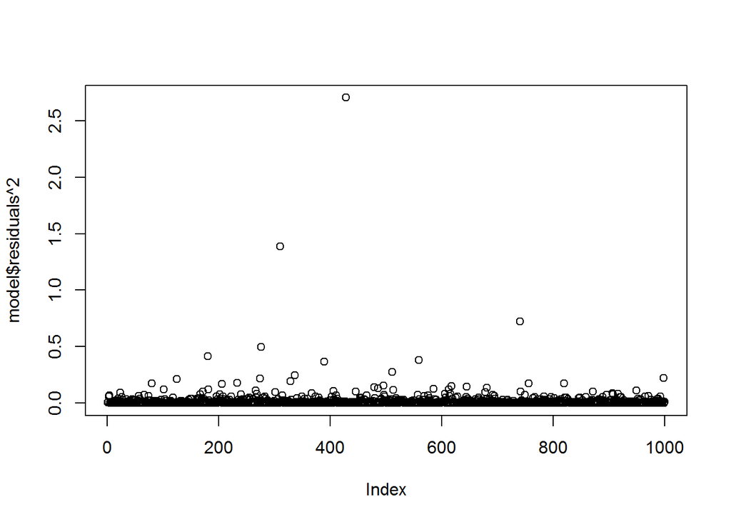

```r
plot(model$residuals ^2)
```

The residuals are normaly distributed with constant variance.

We have some outliers :

```r
head(sort(model$residuals^2, decreasing = TRUE), n = 3) %>%
  pander()
```

| 428 | 310 | 741 |
| --- | --- | --- |
| 2.704 | 1.385 | 0.7208 |

```r
ames_train[c(428, 310, 741), ] %>%
  dplyr::select(price, area, Lot.Area, Neighborhood, Overall.Qual, Year.Built, Exter.Qual, Heating, Sale.Condition, Kitchen.Qual, Bedroom.AbvGr) %>%
  pander()
```

| price | area | Lot.Area | Neighborhood | Overall.Qual | Year.Built | Exter.Qual | Heating | Sale.Condition | Kitchen.Qual | Bedroom.AbvGr |
| --- | --- | --- | --- | --- | --- | --- | --- | --- | --- | --- |
| 12789 | 832 | 9656 | OldTown | 2 | 1923 | TA | GasA | Abnorml | TA | 2 |
| 184750 | 4676 | 40094 | Edwards | 10 | 2007 | Ex | GasA | Partial | Ex | 3 |
| 40000 | 1317 | 8500 | IDOTRR | 4 | 1920 | TA | GasA | Normal | TA | 3 |

### 2.2.4 Section 2.4 Initial Model RMSE

You can calculate it directly based on the model output. Be specific about the units of your RMSE (depending on whether you transformed your response variable). The value you report will be more meaningful if it is in the original units (dollars).

```r
rmse_in_dollar <- sqrt(sum((exp(model$fitted.values) - ames_train$price) ^ 2) / nrow(ames_train))
```

The USD$ RMSE of the model is USD$ 29,786.99

### 2.2.5 Section 2.5 Overfitting

The process of building a model generally involves starting with an initial model (as you have done above), identifying its shortcomings, and adapting the model accordingly. This process may be repeated several times until the model fits the data reasonably well. However, the model may do well on training data but perform poorly out-of-sample (meaning, on a dataset other than the original training data) because the model is overly-tuned to specifically fit the training data. This is called âoverfitting.â To determine whether overfitting is occurring on a model, compare the performance of a model on both in-sample and out-of-sample data sets. To look at performance of your initial model on out-of-sample data, you will use the data set `ames_test`.

```r
load("ames_test.Rdata")
```

Use your model from above to generate predictions for the housing prices in the test data set. Are the predictions significantly more accurate (compared to the actual sales prices) for the training data than the test data? Why or why not? Briefly explain how you determined that (what steps or processes did you use)?

```r
ames_test_normalized <- ames_test %>%
  filter(Neighborhood != 'Landmrk')

test_predictions <- predict(model, newdata = ames_test_normalized)

rmse_test_in_dollar <- sqrt(sum((exp(test_predictions) - ames_test_normalized$price) ^ 2) / nrow(ames_test_normalized))
```

First the test data has a new level (Landmrk) on the `Neighborhood` variable, I had to filter the test data, as the model doesn’t seen this level on training, he is unable to predict values.

The USD$ RMSE of the model is USD$ 24,224.07, smallert than the RMSE on training, so the predictions are accurate.

**Note to the learner:** If in real-life practice this out-of-sample analysis shows evidence that the training data fits your model a lot better than the test data, it is probably a good idea to go back and revise the model (usually by simplifying the model) to reduce this overfitting. For simplicity, we do not ask you to do this on the assignment, however.

## 2.3 Part 3 Development of a Final Model

Now that you have developed an initial model to use as a baseline, create a final model with *at most* 20 variables to predict housing prices in Ames, IA, selecting from the full array of variables in the dataset and using any of the tools that we introduced in this specialization.

Carefully document the process that you used to come up with your final model, so that you can answer the questions below.

### 2.3.1 Section 3.1 Final Model

Provide the summary table for your model.

```r
#select only the used columns and remove the NAs
ames_train_normalized <- ames_train %>%
  dplyr::select(price, area, Lot.Area, Neighborhood, Overall.Qual, Year.Built, Exter.Qual, Heating, Sale.Condition , Kitchen.Qual, Bedroom.AbvGr,
                    TotRms.AbvGrd, Fireplaces, Total.Bsmt.SF, Year.Remod.Add, Roof.Style, Lot.Config, Lot.Frontage,Mas.Vnr.Type, Foundation, Paved.Drive, Garage.Area, Overall.Cond,House.Style) %>%
  na.omit()


#First model (all variables)
final_model <- lm(data = ames_train_normalized,
                  formula = log(price) ~
                    log(area) + log(Lot.Area) + Neighborhood + Overall.Qual + Year.Built + Exter.Qual + Heating + Sale.Condition + Kitchen.Qual + Bedroom.AbvGr +
                    TotRms.AbvGrd + Fireplaces + Total.Bsmt.SF + Year.Remod.Add + Roof.Style + Lot.Config + log(Lot.Frontage) + Mas.Vnr.Type + Foundation + Paved.Drive + Garage.Area + Overall.Cond + House.Style)


#Using BIC to select the final model
stepAIC(final_model, direction = c('both'), k = log(nrow(ames_train_normalized)))
```

```
## Start:  AIC=-2824.09
## log(price) ~ log(area) + log(Lot.Area) + Neighborhood + Overall.Qual +
##     Year.Built + Exter.Qual + Heating + Sale.Condition + Kitchen.Qual +
##     Bedroom.AbvGr + TotRms.AbvGrd + Fireplaces + Total.Bsmt.SF +
##     Year.Remod.Add + Roof.Style + Lot.Config + log(Lot.Frontage) +
##     Mas.Vnr.Type + Foundation + Paved.Drive + Garage.Area + Overall.Cond +
##     House.Style
##
##                     Df Sum of Sq    RSS     AIC
## - Neighborhood      25   1.91502 16.694 -2890.9
## - House.Style        6   0.20481 14.984 -2853.0
## - Roof.Style         4   0.02071 14.800 -2849.8
## - Heating            4   0.03182 14.811 -2849.2
## - Mas.Vnr.Type       4   0.05298 14.832 -2848.0
## - Lot.Config         4   0.11600 14.895 -2844.5
## - Exter.Qual         3   0.00479 14.784 -2844.0
## - Foundation         4   0.12928 14.908 -2843.7
## - Kitchen.Qual       4   0.27236 15.051 -2835.8
## - Paved.Drive        2   0.11901 14.898 -2830.9
## - TotRms.AbvGrd      1   0.00323 14.782 -2830.6
## - log(Lot.Frontage)  1   0.00349 14.783 -2830.6
## - Year.Remod.Add     1   0.03795 14.817 -2828.7
## <none>                           14.779 -2824.1
## - Garage.Area        1   0.12698 14.906 -2823.7
## - Bedroom.AbvGr      1   0.13762 14.917 -2823.1
## - Sale.Condition     5   0.65983 15.439 -2821.4
## - Fireplaces         1   0.22213 15.001 -2818.4
## - log(Lot.Area)      1   0.40978 15.189 -2808.1
## - Total.Bsmt.SF      1   0.45646 15.236 -2805.5
## - Year.Built         1   0.75512 15.534 -2789.4
## - Overall.Qual       1   1.17560 15.955 -2767.2
## - log(area)          1   1.98616 16.765 -2726.0
## - Overall.Cond       1   2.43001 17.209 -2704.3
##
## Step:  AIC=-2890.9
## log(price) ~ log(area) + log(Lot.Area) + Overall.Qual + Year.Built +
##     Exter.Qual + Heating + Sale.Condition + Kitchen.Qual + Bedroom.AbvGr +
##     TotRms.AbvGrd + Fireplaces + Total.Bsmt.SF + Year.Remod.Add +
##     Roof.Style + Lot.Config + log(Lot.Frontage) + Mas.Vnr.Type +
##     Foundation + Paved.Drive + Garage.Area + Overall.Cond + House.Style
```

[output cut: 397 more lines]

```
## + Exter.Qual         3    0.1711 17.847 -3070.7
## - Bedroom.AbvGr      1    0.4614 18.480 -3068.6
## + Foundation         4    0.1540 17.864 -3063.2
## + Lot.Config         4    0.1014 17.917 -3060.7
## + Mas.Vnr.Type       4    0.0685 17.950 -3059.2
## + Heating            4    0.0374 17.981 -3057.8
## + Roof.Style         4    0.0165 18.002 -3056.8
## + House.Style        6    0.1209 17.897 -3048.2
## + Neighborhood      25    2.1474 15.871 -3020.3
## - log(Lot.Area)      1    1.7860 19.804 -3011.1
## - Total.Bsmt.SF      1    1.9284 19.946 -3005.2
## - Overall.Qual       1    3.9278 21.946 -2925.8
## - Overall.Cond       1    4.3761 22.394 -2909.0
## - log(area)          1    4.9245 22.942 -2888.9
## - Year.Built         1    5.6097 23.628 -2864.4
```

```
##
## Call:
## lm(formula = log(price) ~ log(area) + log(Lot.Area) + Overall.Qual +
##     Year.Built + Sale.Condition + Bedroom.AbvGr + Fireplaces +
##     Total.Bsmt.SF + Garage.Area + Overall.Cond, data = ames_train_normalized)
##
## Coefficients:
##           (Intercept)              log(area)          log(Lot.Area)
##            -1.1486047              0.4424266              0.1077975
##          Overall.Qual             Year.Built  Sale.ConditionAdjLand
##             0.0860265              0.0039550              0.1557943
##  Sale.ConditionAlloca   Sale.ConditionFamily   Sale.ConditionNormal
##             0.1896697              0.0151466              0.1105924
## Sale.ConditionPartial          Bedroom.AbvGr             Fireplaces
##             0.1464594             -0.0392335              0.0395779
##         Total.Bsmt.SF            Garage.Area           Overall.Cond
##             0.0001519              0.0001198              0.0760383
```

```r
#Fit the final model
final_model <- lm(data = ames_train_normalized,
                  formula = log(price) ~ log(area) + log(Lot.Area) + Overall.Qual + Year.Built +
    Sale.Condition + Bedroom.AbvGr + Fireplaces + Total.Bsmt.SF +
    Garage.Area + Overall.Cond)

#summary(final_model)

#Calculat the RMSE on ames_train
final_model_rmse_train_in_dollar <- sqrt(sum((exp(final_model$fitted.values) - ames_train_normalized$price) ^ 2) / nrow(ames_train_normalized))

#Calculat the RMSE on ames_test
final_model_test_predictions <- predict(final_model, newdata = ames_test_normalized)
final_model_rmse_test_in_dollar <- sqrt(sum((exp(final_model_test_predictions) - ames_test_normalized$price) ^ 2) / nrow(ames_test_normalized))
```

### 2.3.2 Section 3.2 Transformation

Did you decide to transform any variables? Why or why not? Explain in a few sentences.

### 2.3.3 Section 3.3 Variable Interaction

Did you decide to include any variable interactions? Why or why not? Explain in a few sentences.

As I’m a quite late to do the exercice I decide to skip this variable interactions.

### 2.3.4 Section 3.4 Variable Selection

What method did you use to select the variables you included? Why did you select the method you used? Explain in a few sentences.

I’m using the BIC stepwise criteria, to get the best simplest model possible.

### 2.3.5 Section 3.5 Model Testing

How did testing the model on out-of-sample data affect whether or how you changed your model? Explain in a few sentences.

On a real-life case we need to run from overfitting , so testing the model on a out-of-sample will give to us the notion if the model is overfitting or not. If yes, we need to return to modeling and adjust the variables.

## 2.4 Part 4 Final Model Assessment

### 2.4.1 Section 4.1 Final Model Residual

For your final model, create and briefly interpret an informative plot of the residuals.

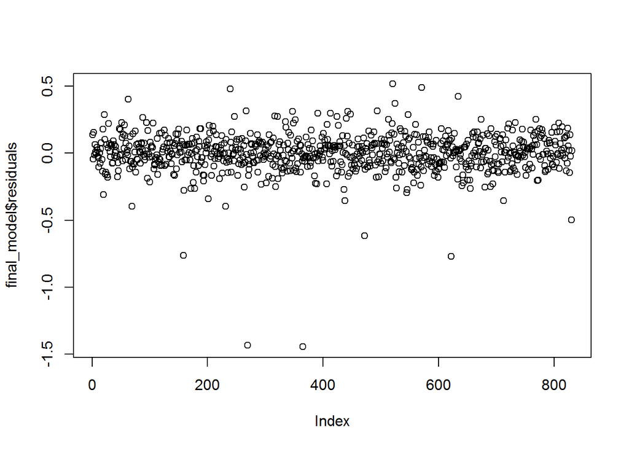

```r
plot(final_model$residuals)
```

```r
head(sort(final_model$residuals^2, decreasing = TRUE), n = 3) %>%
  pander()
```

| 365 | 269 | 622 |
| --- | --- | --- |
| 2.091 | 2.059 | 0.5951 |

```r
ames_train[c(365, 269, 622), ] %>%
  dplyr::select(price, area, Lot.Area, Neighborhood, Overall.Qual, Year.Built, Exter.Qual, Heating, Sale.Condition , Kitchen.Qual, Bedroom.AbvGr,
                    TotRms.AbvGrd, Fireplaces, Total.Bsmt.SF, Year.Remod.Add, Roof.Style, Lot.Config, Lot.Frontage,Mas.Vnr.Type, Foundation, Paved.Drive, Garage.Area, Overall.Cond,House.Style) %>%
  pander()
```

| price | area | Lot.Area | Neighborhood | Overall.Qual | Year.Built | Exter.Qual | Heating | Sale.Condition | Kitchen.Qual | Bedroom.AbvGr | TotRms.AbvGrd | Fireplaces | Total.Bsmt.SF | Year.Remod.Add | Roof.Style | Lot.Config | Lot.Frontage | Mas.Vnr.Type | Foundation | Paved.Drive | Garage.Area | Overall.Cond | House.Style |
| --- | --- | --- | --- | --- | --- | --- | --- | --- | --- | --- | --- | --- | --- | --- | --- | --- | --- | --- | --- | --- | --- | --- | --- |
| 149900 | 1078 | 12537 | NAmes | 5 | 1971 | TA | GasA | Normal | TA | 3 | 6 | 1 | 1078 | 2008 | Gable | CulDSac | NA | None | CBlock | Y | 500 | 6 | 1Story |
| 170000 | 1374 | 9434 | Gilbert | 7 | 2004 | Gd | GasA | Normal | Gd | 3 | 6 | 1 | 384 | 2005 | Gable | Inside | 59 | None | PConc | Y | 400 | 5 | SLvl |
| 215000 | 1602 | 16635 | NWAmes | 6 | 1977 | Gd | GasA | Normal | Gd | 3 | 8 | 1 | 1602 | 2000 | Gable | FR2 | NA | Stone | CBlock | Y | 529 | 7 | 1Story |

### 2.4.2 Section 4.2 Final Model RMSE

For your final model, calculate and briefly comment on the RMSE.

The USD$ train RMSE of the model is USD$ 32,260.10.

The USD$ test RMSE of the model is USD$ 21,814.26.

As the RMSE on test is less than on training we can assume that there is no overfitting occurring here.

### 2.4.3 Section 4.3 Final Model Evaluation

What are some strengths and weaknesses of your model?

**strengths** : the model generalize well, and has a low RMSE on test set. **weaknesses** : if a new instance of house came with new levels the model is unable to predict the price.

### 2.4.4 Section 4.4 Final Model Validation

Testing your final model on a separate, validation data set is a great way to determine how your model will perform in real-life practice.

You will use the âames_validationâ dataset to do some additional assessment of your final model. Discuss your findings, be sure to mention: * What is the RMSE of your final model when applied to the validation data?  
* How does this value compare to that of the training data and/or testing data? * What percentage of the 95% predictive confidence (or credible) intervals contain the true price of the house in the validation data set?  
* From this result, does your final model properly reflect uncertainty?

```r
load("ames_validation.Rdata")
```

```r
validation_predictions <- predict(final_model, newdata = ames_validation, interval="predict", level = 0.95) %>%
  as.data.frame()

rmse_validation_in_dollar <- sqrt(sum((exp(validation_predictions$fit) - ames_validation$price) ^ 2) / nrow(ames_validation))

newdata <- data.frame(exp(validation_predictions), price = ames_validation$price)
```

The USD$ RMSE of the model is USD$ 21,316.99, smallert than the RMSE on training and tesing, so the predictions are accurate.

Checking with the C.I. of 95% how many predicions contain the true value:

```r
newdata %>%
  mutate(in_credible_interval = (price >= lwr && price <= upr)) %>%
  group_by(in_credible_interval) %>%
  summarise(total = n() / nrow(newdata) * 100) %>%
  pander()
```

| in_credible_interval | total |
| --- | --- |
| TRUE | 100 |

## 2.5 Part 5 Conclusion

Provide a brief summary of your results, and a brief discussion of what you have learned about the data and your model.

NA values has a huge impact on with variables whe pick to the model.

The final model performs very well, the RMSE decreases on each data set.

BIC selection criteria selects a good, and samll, model.

Transform the response variable to `log` helps to build a better model, but can be tricky when you are calculating the RMSE.

It was fun!